# Cinema Tickets clustering analysis

Duae Mariam

2023-02-28

### Introduction

Clustering and dimension reduction can be used in various ways, in several combinations; however, there are some field for which the clustering studies are not applicable. certain market or field specific dynamics do not allow us to perform USL studies based on the market specific factors. The clustering studies are numerous for understanding market segmentation and understanding consumer base. I have tried to create such a study based on viewership of certain movies across several cities in world. I expect to see some interesting insights from the study.

```r
library(factoextra)
library(devtools)

library(flexclust)
library(clustertend)
library(cluster)
library(ClusterR)
library(gridExtra)
library(corrplot)
```

### Importing the dataset(CSV format)

```r
data <- read.csv("cinemaTicket_Ref.csv")
names(data)
```

```
##  [1] "film_code"    "city"         "tickets_sold" "tickets_out"  "show_time"
##  [6] "occu_perc"    "ticket_price" "ticket_use"   "capacity"     "date"
## [11] "month"        "quarter"      "day"          "total_sales"
```

### About the dataset

The dataset includes 1 film_code - this is the Movie identifier

2 city - the city where the movie was screened

3 tickets_sold - total tickets sold

4 tickets_out - total tickets not sold

5 show_time - run time of a particular movie

6 occu_perc - percentage measure of occupancy

7 ticket_price - price of the ticket indonesian

8 ticket_use - how many tickets were used

9 capacity - capacity of the cinema in one screening

10 date

11 month

12 quarter

13 day

14 total_sales - total sales made for a movie in particular screening

### Basic Exploratory Data Analysis

#### Viewing some initial observations

```r
head(data)
```

```
##   film_code       city tickets_sold tickets_out show_time occu_perc
## 1      1563      Tokyo          210           0         5     41.18
## 2      1499    Jakarta          210           0         9     16.41
## 3      1497      Delhi          211           0         6     11.24
## 4      1497     Manila          211           0         2     81.15
## 5      1494 SÃ£o Paulo          211           0         5     37.15
## 6      1494      Seoul          211           0         3     44.23
##   ticket_price ticket_use  capacity       date month quarter day total_sales
## 1      60000.0        210  509.9563  11/9/2018     9       3  11    12600000
## 2     150000.0        210 1279.7075 26/07/2018     7       3  26    31500000
## 3      35000.0        211 1877.2242 29/05/2018     5       2  29     7385000
## 4      40000.0        211  260.0123 15/05/2018     5       2  15     8440000
## 5     119146.9        211  567.9677 24/05/2018     5       2  24    25140000
## 6      50000.0        211  477.0518 21/07/2018     7       3  21    10550000
```

#### Structure of the dataset

```r
str(data)
```

```
## 'data.frame':    305 obs. of  14 variables:
##  $ film_code   : int  1563 1499 1497 1497 1494 1494 1494 1494 1494 1496 ...
##  $ city        : chr  "Tokyo" "Jakarta" "Delhi" "Manila" ...
##  $ tickets_sold: int  210 210 211 211 211 211 211 211 211 211 ...
##  $ tickets_out : int  0 0 0 0 0 0 0 0 0 0 ...
##  $ show_time   : int  5 9 6 2 5 3 3 3 4 5 ...
##  $ occu_perc   : num  41.2 16.4 11.2 81.2 37.1 ...
##  $ ticket_price: num  60000 150000 35000 40000 119147 ...
##  $ ticket_use  : int  210 210 211 211 211 211 211 211 211 211 ...
##  $ capacity    : num  510 1280 1877 260 568 ...
##  $ date        : chr  "11/9/2018" "26/07/2018" "29/05/2018" "15/05/2018" ...
##  $ month       : int  9 7 5 5 5 7 6 5 5 5 ...
##  $ quarter     : int  3 3 2 2 2 3 2 2 2 2 ...
##  $ day         : int  11 26 29 15 24 21 22 29 29 24 ...
##  $ total_sales : int  12600000 31500000 7385000 8440000 25140000 10550000 31650000 16880000 12660000 14760000 ...
```

```r
summary(data)
```

```
##    film_code        city            tickets_sold    tickets_out
##  Min.   :1486   Length:305         Min.   :210.0   Min.   : 0.0000
##  1st Qu.:1494   Class :character   1st Qu.:215.0   1st Qu.: 0.0000
##  Median :1497   Mode  :character   Median :218.0   Median : 0.0000
##  Mean   :1501                      Mean   :218.7   Mean   : 0.2754
##  3rd Qu.:1499                      3rd Qu.:223.0   3rd Qu.: 0.0000
##  Max.   :1566                      Max.   :228.0   Max.   :14.0000
##    show_time        occu_perc       ticket_price      ticket_use
##  Min.   : 1.000   Min.   :  2.51   Min.   : 24667   Min.   :206.0
##  1st Qu.: 3.000   1st Qu.: 22.84   1st Qu.: 58889   1st Qu.:215.0
##  Median : 4.000   Median : 35.19   Median : 80000   Median :218.0
##  Mean   : 4.993   Mean   : 39.94   Mean   : 89524   Mean   :218.5
##  3rd Qu.: 6.000   3rd Qu.: 52.45   3rd Qu.:129005   3rd Qu.:223.0
##  Max.   :18.000   Max.   :103.08   Max.   :150000   Max.   :228.0
##     capacity          date               month           quarter
##  Min.   : 207.6   Length:305         Min.   : 3.000   Min.   :1.000
##  1st Qu.: 422.0   Class :character   1st Qu.: 5.000   1st Qu.:2.000
##  Median : 623.9   Mode  :character   Median : 6.000   Median :2.000
##  Mean   : 855.8                      Mean   : 6.085   Mean   :2.377
##  3rd Qu.: 980.0                      3rd Qu.: 7.000   3rd Qu.:3.000
##  Max.   :8446.2                      Max.   :10.000   Max.   :4.000
##       day         total_sales
##  Min.   : 1.00   Min.   : 5300000
##  1st Qu.:11.00   1st Qu.:12600000
##  Median :17.00   Median :17600000
##  Mean   :17.07   Mean   :19597475
##  3rd Qu.:24.00   3rd Qu.:28510000
##  Max.   :31.00   Max.   :33900000
```

## Data Cleaning and Dimnesion Reduction

**Some of the techniques of Dimnesion Reduction used in the analysis below are:**

**Principal Component Analysis (PCA) , Missing Value elimination, Low Variance Filter, High Correlation filter**

### Removing the NA values from the dataset

```r
sapply(data, function(x) sum(is.na(x)))
```

```
##    film_code         city tickets_sold  tickets_out    show_time    occu_perc
##            0            0            0            0            0            0
## ticket_price   ticket_use     capacity         date        month      quarter
##            0            0            0            0            0            0
##          day  total_sales
##            0            0
```

```r
complete_rows <- complete.cases(data[ , c("occu_perc", "capacity")])
data <- data[complete_rows,]

sapply(data, function(x) sum(is.na(x)))
```

```
##    film_code         city tickets_sold  tickets_out    show_time    occu_perc
##            0            0            0            0            0            0
## ticket_price   ticket_use     capacity         date        month      quarter
##            0            0            0            0            0            0
##          day  total_sales
##            0            0
```

## Dimension reduction

```r
str(data)
```

```
## 'data.frame':    305 obs. of  14 variables:
##  $ film_code   : int  1563 1499 1497 1497 1494 1494 1494 1494 1494 1496 ...
##  $ city        : chr  "Tokyo" "Jakarta" "Delhi" "Manila" ...
##  $ tickets_sold: int  210 210 211 211 211 211 211 211 211 211 ...
##  $ tickets_out : int  0 0 0 0 0 0 0 0 0 0 ...
##  $ show_time   : int  5 9 6 2 5 3 3 3 4 5 ...
##  $ occu_perc   : num  41.2 16.4 11.2 81.2 37.1 ...
##  $ ticket_price: num  60000 150000 35000 40000 119147 ...
##  $ ticket_use  : int  210 210 211 211 211 211 211 211 211 211 ...
##  $ capacity    : num  510 1280 1877 260 568 ...
##  $ date        : chr  "11/9/2018" "26/07/2018" "29/05/2018" "15/05/2018" ...
##  $ month       : int  9 7 5 5 5 7 6 5 5 5 ...
##  $ quarter     : int  3 3 2 2 2 3 2 2 2 2 ...
##  $ day         : int  11 26 29 15 24 21 22 29 29 24 ...
##  $ total_sales : int  12600000 31500000 7385000 8440000 25140000 10550000 31650000 16880000 12660000 14760000 ...
```

```r
summary(data)
```

```
##    film_code        city            tickets_sold    tickets_out
##  Min.   :1486   Length:305         Min.   :210.0   Min.   : 0.0000
##  1st Qu.:1494   Class :character   1st Qu.:215.0   1st Qu.: 0.0000
##  Median :1497   Mode  :character   Median :218.0   Median : 0.0000
##  Mean   :1501                      Mean   :218.7   Mean   : 0.2754
##  3rd Qu.:1499                      3rd Qu.:223.0   3rd Qu.: 0.0000
##  Max.   :1566                      Max.   :228.0   Max.   :14.0000
##    show_time        occu_perc       ticket_price      ticket_use
##  Min.   : 1.000   Min.   :  2.51   Min.   : 24667   Min.   :206.0
##  1st Qu.: 3.000   1st Qu.: 22.84   1st Qu.: 58889   1st Qu.:215.0
##  Median : 4.000   Median : 35.19   Median : 80000   Median :218.0
##  Mean   : 4.993   Mean   : 39.94   Mean   : 89524   Mean   :218.5
##  3rd Qu.: 6.000   3rd Qu.: 52.45   3rd Qu.:129005   3rd Qu.:223.0
##  Max.   :18.000   Max.   :103.08   Max.   :150000   Max.   :228.0
##     capacity          date               month           quarter
##  Min.   : 207.6   Length:305         Min.   : 3.000   Min.   :1.000
##  1st Qu.: 422.0   Class :character   1st Qu.: 5.000   1st Qu.:2.000
##  Median : 623.9   Mode  :character   Median : 6.000   Median :2.000
##  Mean   : 855.8                      Mean   : 6.085   Mean   :2.377
##  3rd Qu.: 980.0                      3rd Qu.: 7.000   3rd Qu.:3.000
##  Max.   :8446.2                      Max.   :10.000   Max.   :4.000
##       day         total_sales
##  Min.   : 1.00   Min.   : 5300000
##  1st Qu.:11.00   1st Qu.:12600000
##  Median :17.00   Median :17600000
##  Mean   :17.07   Mean   :19597475
##  3rd Qu.:24.00   3rd Qu.:28510000
##  Max.   :31.00   Max.   :33900000
```

### Eliiminating the Columns which are unnecessary the Film code and date

```r
data <- data[,c(-1,-10)]
```

### Scaling the variables for easier analysis of clustering

```r
data$ticket_price <- data$ticket_price/mean(data$ticket_price)

data$total_sales <- data$total_sales/mean(data$total_sales)
```

### Checking correlation among variables

```r
correlation <- cor(data[,-1], method = 'pearson')
round(correlation, 2) # Rounding off the values to 2 decimal digits
```

```
##              tickets_sold tickets_out show_time occu_perc ticket_price
## tickets_sold         1.00        0.05     -0.04     -0.06         0.07
## tickets_out          0.05        1.00      0.08     -0.06         0.03
## show_time           -0.04        0.08      1.00     -0.55         0.18
## occu_perc           -0.06       -0.06     -0.55      1.00        -0.21
## ticket_price         0.07        0.03      0.18     -0.21         1.00
## ticket_use           0.96       -0.22     -0.06     -0.04         0.07
## capacity            -0.02        0.17      0.60     -0.63        -0.03
## month                0.01       -0.03     -0.05      0.01        -0.16
## quarter              0.02       -0.05     -0.13      0.11        -0.13
## day                 -0.03        0.01      0.01     -0.04         0.02
## total_sales          0.12        0.03      0.18     -0.21         1.00
##              ticket_use capacity month quarter   day total_sales
## tickets_sold       0.96    -0.02  0.01    0.02 -0.03        0.12
## tickets_out       -0.22     0.17 -0.03   -0.05  0.01        0.03
## show_time         -0.06     0.60 -0.05   -0.13  0.01        0.18
## occu_perc         -0.04    -0.63  0.01    0.11 -0.04       -0.21
## ticket_price       0.07    -0.03 -0.16   -0.13  0.02        1.00
## ticket_use         1.00    -0.07  0.01    0.03 -0.03        0.11
## capacity          -0.07     1.00  0.00   -0.08 -0.01       -0.02
## month              0.01     0.00  1.00    0.88 -0.21       -0.16
## quarter            0.03    -0.08  0.88    1.00 -0.18       -0.13
## day               -0.03    -0.01 -0.21   -0.18  1.00        0.02
## total_sales        0.11    -0.02 -0.16   -0.13  0.02        1.00
```

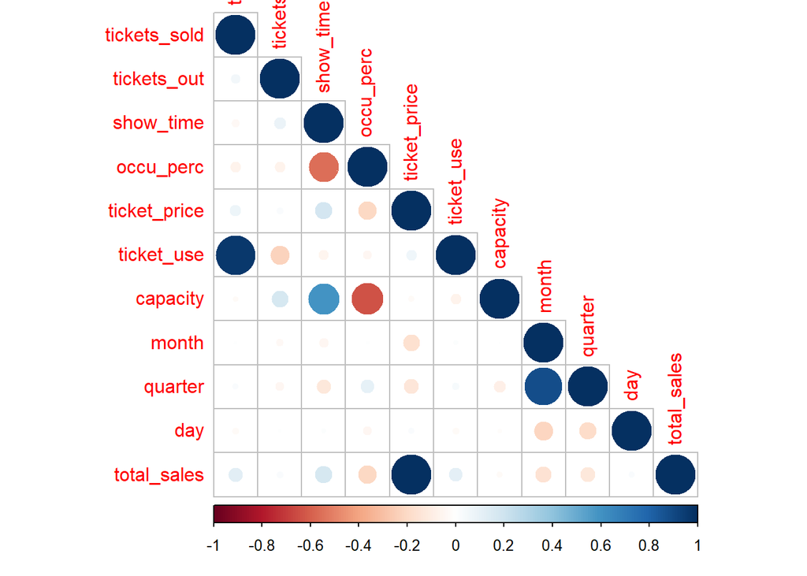

```r
corrplot(correlation, type = 'lower')
```

The plot clearly shows that there are some variables which are correlated with some other variables in the dataset. This means we can use some dimension reduction techniques for easy computation of the analysis.

### Principal Component Analysis(PCA)

#### Finding optimal number of components

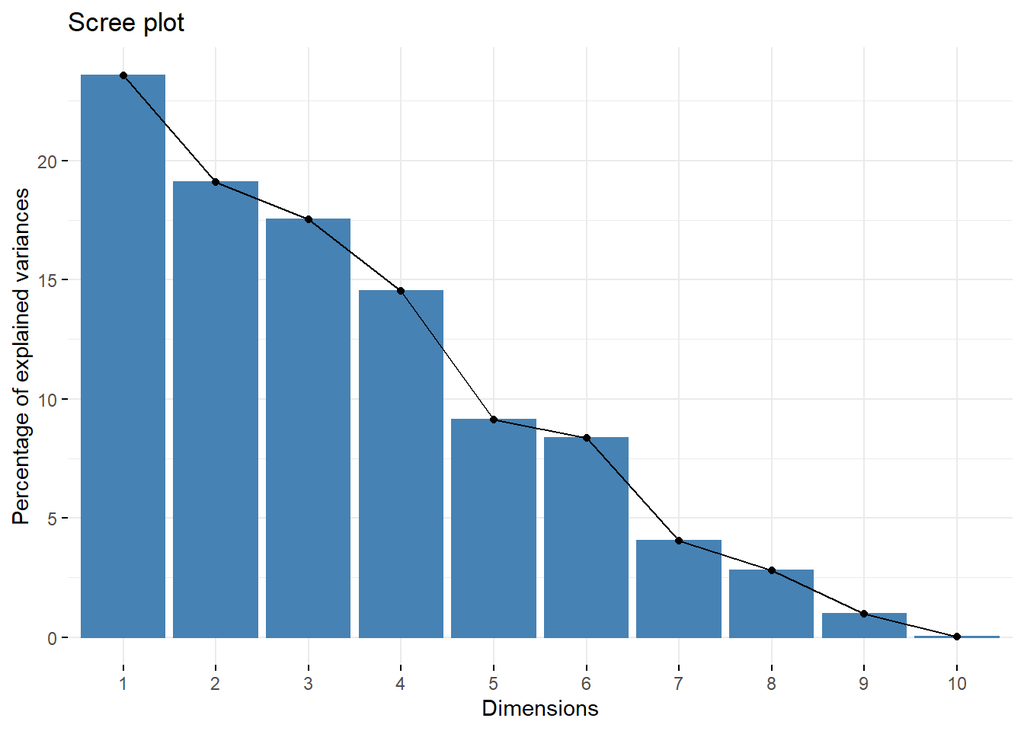

```r
pca <- prcomp(data[,-1], center=TRUE, scale=TRUE)

fviz_eig(pca)
```

```r
summary(pca)
```

```
## Importance of components:
##                           PC1    PC2    PC3    PC4     PC5     PC6    PC7
## Standard deviation     1.6105 1.4495 1.3881 1.2641 1.00145 0.95819 0.6675
## Proportion of Variance 0.2358 0.1910 0.1752 0.1453 0.09117 0.08347 0.0405
## Cumulative Proportion  0.2358 0.4268 0.6020 0.7472 0.83841 0.92188 0.9624
##                           PC8    PC9    PC10      PC11
## Standard deviation     0.5540 0.3267 0.01549 2.576e-15
## Proportion of Variance 0.0279 0.0097 0.00002 0.000e+00
## Cumulative Proportion  0.9903 1.0000 1.00000 1.000e+00
```

Lets now check the eigen values of the correlation.

```r
eigen(cor(data[-1]))$values
```

```
##  [1]  2.593704e+00  2.101049e+00  1.926795e+00  1.598042e+00  1.002911e+00
##  [6]  9.181299e-01  4.454957e-01  3.068999e-01  1.067352e-01  2.398610e-04
## [11] -2.050952e-16
```

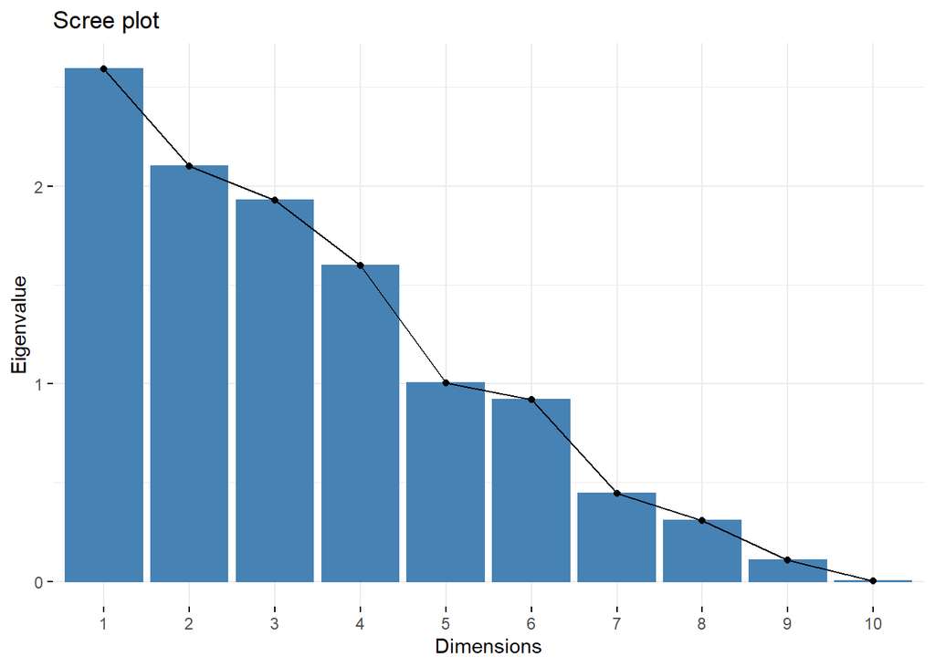

```r
fviz_eig(pca, choice='eigenvalue')
```

Looking at the results above and also by the Scree-plot, it becomes clear that there are 5 variables with an eigen value of more than 1. As a general thumb rule, it is a good practice to select those variables which has eigen value of 1 or more. This means the first five variables will be good for further analysis.